# Elección de modelos

Héctor Nájera

# 1 Introducción

En este ejercicio exploramos cómo diferentes decisiones de modelado pueden afectar la capacidad de un modelo bayesiano para representar y predecir correctamente el crecimiento económico. Utilizamos datos simulados que representan la tasa anual de crecimiento del PIB per cápita, modelada en función de tres factores clave:

- La tasa de crecimiento de la inversión tecnológica rezagada un año (inversion_lag1),
- El crecimiento en años promedio de educación (educacion),
- Y una variable indicadora de política pública implementada a mitad del periodo observado (politica).

El objetivo es mostrar cómo el desempeño de distintos modelos puede variar al modificar dos aspectos fundamentales:

- La distribución asumida para los errores: se comparan modelos con errores normales, lognormales y skew-normal (asimétricos).
- La estructura temporal del modelo: se contrasta un modelo estándar con otro que incorpora autocorrelación temporal AR(1) en los errores, lo que permite capturar dependencias entre los años consecutivos.

A través de la estimación con brms (usando cmdstanr como backend) y el uso del criterio Leave-One-Out cross-validation (LOO), se evalúa la capacidad predictiva de cada modelo. Esto permite identificar si incorporar la autocorrelación o suponer distribuciones más flexibles mejora el ajuste a los datos.

## 1.1 Hipótesis

La hipótesis es que el creicmiento de la inversión en tecnología tiene un efecto positivo de entre .1 y .5 puntos porcentuales sobre el PIB.

# 2 Cargamos los datos

```r
load("datos")
```

```r
head(datos)
```

```
## # A tibble: 6 × 6
##    anio pib_crecimiento inversion educacion politica inversion_lag1
##   <int>           <dbl>     <dbl>     <dbl> <fct>             <dbl>
## 1  1961            1.24      2.54     0.849 0                  1.88
## 2  1962            2.98      6.12     0.900 0                  2.54
## 3  1963            5.47      3.14     0.694 0                  6.12
## 4  1964            5.20      3.26     0.678 0                  3.14
## 5  1965            3.37      6.43     1.09  0                  3.26
## 6  1966            5.46      3.92     1.13  0                  6.43
```

# 3 Descriptivos

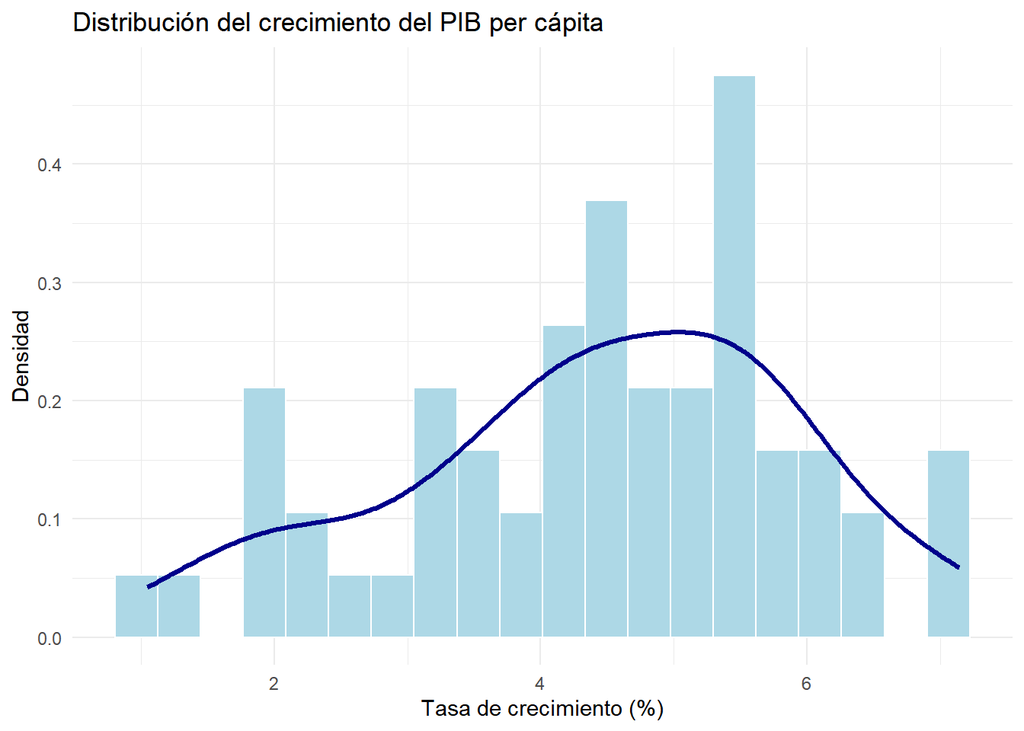

```r
library(ggplot2)

ggplot(datos, aes(x = pib_crecimiento)) +
  geom_histogram(aes(y = ..density..), bins = 20, fill = "lightblue", color = "white") +
  geom_density(color = "darkblue", size = 1.2) +
  labs(
    title = "Distribución del crecimiento del PIB per cápita",
    x = "Tasa de crecimiento (%)",
    y = "Densidad"
  ) +
  theme_minimal()
```

# 4 Modelo 1: con distribución normal y efectos contemporáneos

## 4.1 Modelo generativo

El siguiente modelo asume que la tasa de crecimiento del PIB per cápita sigue una distribución normal, con media determinada por una combinación lineal de predictores:

$$\begin{align*}
y_t &\sim \mathcal{N}(\mu_t, \sigma) \\
\mu_t &= \alpha + \beta_1 \cdot \text{inversion}_t + \beta_2 \cdot
\text{educacion}_t + \beta_3 \cdot \text{politica}_t
\end{align*}$$

Donde:

- $y_t$ es la tasa de crecimiento del PIB per cápita en el año $t$,
- $\text{inversion}_t$ es la tasa de crecimiento de inversión en tecnología,
- $\text{educacion}_t$ es el crecimiento en escolaridad promedio,
- $\text{politica}_t \in \{0, 1\}$ indica la presencia de una política pública.

Los parámetros del modelo siguen las siguientes distribuciones a priori:

$$\begin{align*}
\alpha &\sim \mathcal{N}(0, 1) \\
\beta_j &\sim \mathcal{N}(0, 1) \quad \text{para } j = 1, 2, 3 \\
\sigma &\sim \text{Exponencial}(1)
\end{align*}$$

## 4.2 Estimación

Este modelo es estimado usando `brms()` con el backend de `cmdstanr`, con muestreo en 4 cadenas y 2000 iteraciones cada una, aprovechando 4 hilos de ejecución.

```r
modelo_normal <- brm(
  pib_crecimiento ~ inversion + educacion + politica,
  data = datos,
  family = gaussian(),
  backend = "cmdstanr",
  threads = threading(4),
  prior = c(
    prior(normal(0, 1), class = "b"),
    prior(normal(0, 1), class = "Intercept"),
    prior(exponential(1), class = "sigma")
  ),
  chains = 4, iter = 2000, seed = 123, cores=8,
)
```

[output not shown]

[output cut: 43 more lines]

```
## Chain 4 Iteration: 1400 / 2000 [ 70%]  (Sampling)
## Chain 4 Iteration: 1500 / 2000 [ 75%]  (Sampling)
## Chain 4 Iteration: 1600 / 2000 [ 80%]  (Sampling)
## Chain 4 Iteration: 1700 / 2000 [ 85%]  (Sampling)
## Chain 4 Iteration: 1800 / 2000 [ 90%]  (Sampling)
## Chain 4 Iteration: 1900 / 2000 [ 95%]  (Sampling)
## Chain 4 Iteration: 2000 / 2000 [100%]  (Sampling)
## Chain 1 finished in 0.1 seconds.
## Chain 2 finished in 0.1 seconds.
## Chain 3 finished in 0.1 seconds.
## Chain 4 finished in 0.1 seconds.
##
## All 4 chains finished successfully.
## Mean chain execution time: 0.1 seconds.
## Total execution time: 61.0 seconds.
```

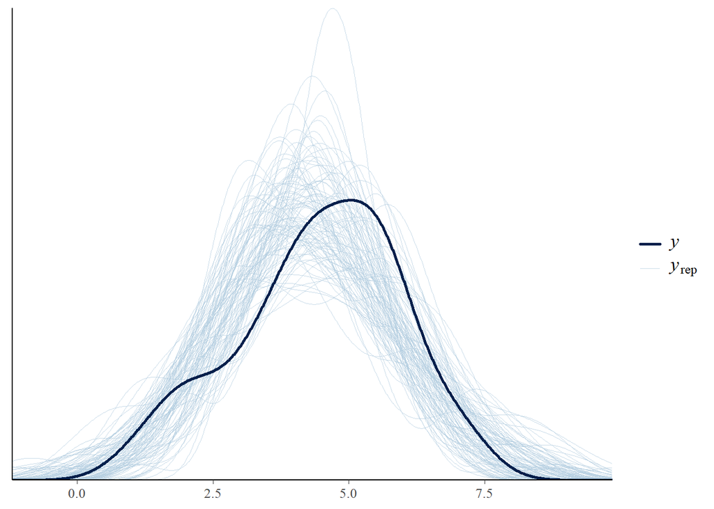

```r
pp_check(modelo_normal, nsamples = 100)
```

# 5 Modelo 1: AR(1)

## 5.1 Modelo

El siguiente modelo asume que la tasa de crecimiento del PIB per cápita sigue una distribución normal, con media determinada por una combinación lineal de predictores. Además, los **errores del modelo están autocorrelacionados en el tiempo** siguiendo una estructura autorregresiva de primer orden (AR(1)):

$$\begin{align*}
y_t &\sim \mathcal{N}(\mu_t, \sigma) \\
\mu_t &= \alpha + \beta_1 \cdot \text{inversion}_{t-1} + \beta_2
\cdot \text{educacion}_t + \beta_3 \cdot \text{politica}_t \\
\varepsilon_t &= y_t - \mu_t \\
\varepsilon_t &= \rho \cdot \varepsilon_{t-1} + \eta_t, \quad \eta_t
\sim \mathcal{N}(0, \sigma_{\text{err}})
\end{align*}$$

Donde:

- $y_t$ es la tasa de crecimiento del PIB per cápita en el año $t$,
- $\text{inversion}_{t-1}$ es la tasa de inversión rezagada un año,
- $\text{educacion}_t$ es el crecimiento en escolaridad promedio,
- $\text{politica}_t \in \{0, 1\}$ indica la presencia de una política pública,
- $\rho$ es el coeficiente de autocorrelación AR(1) entre los errores.

Después de calcular la media, los **residuos del modelo** se definen como:

$$\varepsilon_t = y_t - \mu_t$$

En lugar de asumir que estos errores son independientes, aquí se modela que los errores están **correlacionados en el tiempo** usando una estructura **autorregresiva de primer orden (AR(1))**:

$$\varepsilon_t = \rho \cdot \varepsilon_{t-1} + \eta_t \quad \text{con}
\quad \eta_t \sim \mathcal{N}(0, \sigma_{\text{err}})$$

Esto quiere decir que el error en el año $t$ **depende del error del año anterior**, escalado por un parámetro de autocorrelación $\rho$, más un nuevo término aleatorio $\eta_t$ que sigue una distribución normal con media cero y desviación estándar $\sigma_{\text{err}}$.

Los parámetros del modelo siguen distribuciones a priori no informativas o débilmente informativas (por defecto en este caso). Esta especificación permite capturar dependencias temporales residuales que no son explicadas directamente por los predictores.

Esto indica que estás modelando la autocorrelación en los errores usando un modelo autorregresivo de orden 1 (AR(1)). Esta es una función de brms (y basada en nlme) que especifica una estructura de autocorrelación temporal.

Este es un modelo de fórmula de grupo temporal, que se interpreta como:

1: no hay agrupación. Aplica la autocorrelación a toda la serie completa (es decir, un único grupo con estructura temporal). p=2 sería un AR(2)

```r
modelo_ar_error <- brm(
  pib_crecimiento ~ inversion_lag1 + educacion + politica,
  data = datos,
  family = gaussian(),
   backend = "cmdstanr",
  autocor = cor_ar(~ anio | 1, p = 1),
  chains = 4, iter = 2000, seed = 123, cores=10,
)
```

[output not shown]

[output cut: 43 more lines]

```
## Chain 4 Iteration: 1400 / 2000 [ 70%]  (Sampling)
## Chain 4 Iteration: 1500 / 2000 [ 75%]  (Sampling)
## Chain 1 finished in 0.1 seconds.
## Chain 2 finished in 0.1 seconds.
## Chain 3 finished in 0.1 seconds.
## Chain 4 Iteration: 1600 / 2000 [ 80%]  (Sampling)
## Chain 4 Iteration: 1700 / 2000 [ 85%]  (Sampling)
## Chain 4 Iteration: 1800 / 2000 [ 90%]  (Sampling)
## Chain 4 Iteration: 1900 / 2000 [ 95%]  (Sampling)
## Chain 4 Iteration: 2000 / 2000 [100%]  (Sampling)
## Chain 4 finished in 0.1 seconds.
##
## All 4 chains finished successfully.
## Mean chain execution time: 0.1 seconds.
## Total execution time: 61.0 seconds.
```

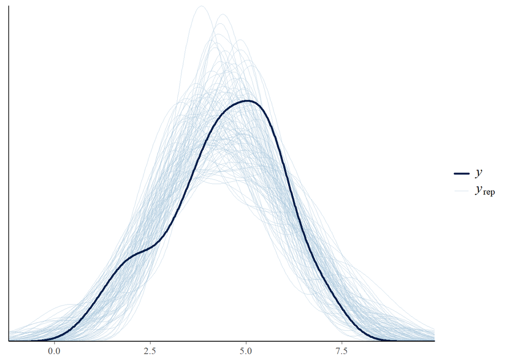

```r
pp_check(modelo_ar_error, nsamples = 100)
```

## 5.2 Verificación de residuos

Al igual que en la inferencia clásica nos gustaría contar con un modelo que no lleve a patrones sistemáticos en los residuales y que no exista algún tipo de autocorrelación serial (dependencia temporal).

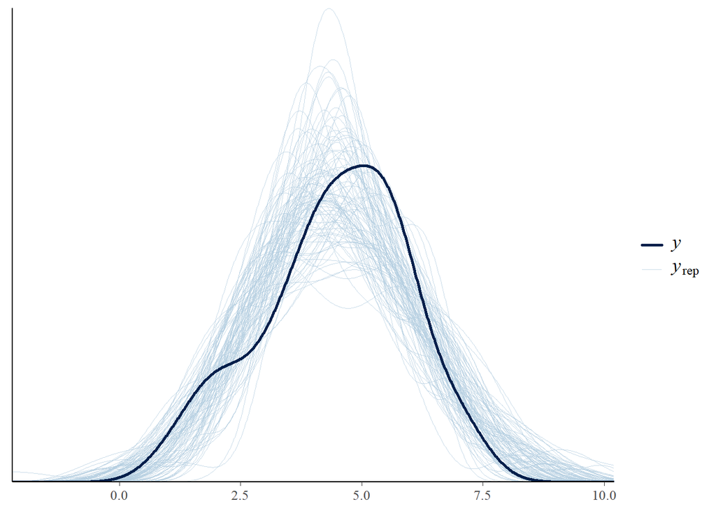

```r
pp_check(modelo_ar_error, type = "dens_overlay", nsamples = 100)
```

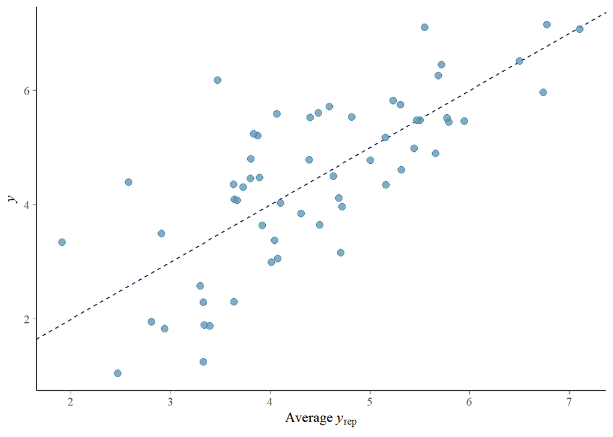

```r
pp_check(modelo_ar_error, type = "scatter_avg")  # residuales vs media
```

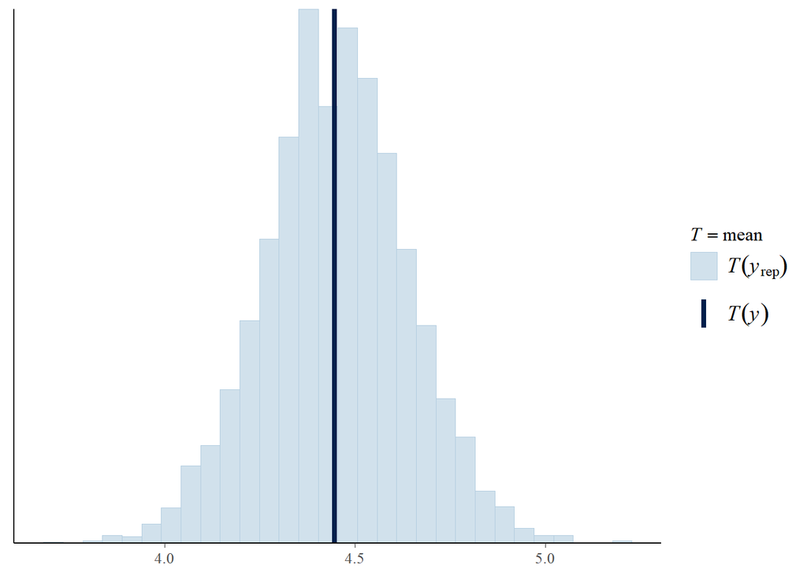

```r
pp_check(modelo_ar_error, type = "stat", stat = "mean")
```

```r
residuos <- residuals(modelo_ar_error, summary = FALSE)
dim(residuos)  # [n, iteraciones]
```

```
## [1] 4000   59
```

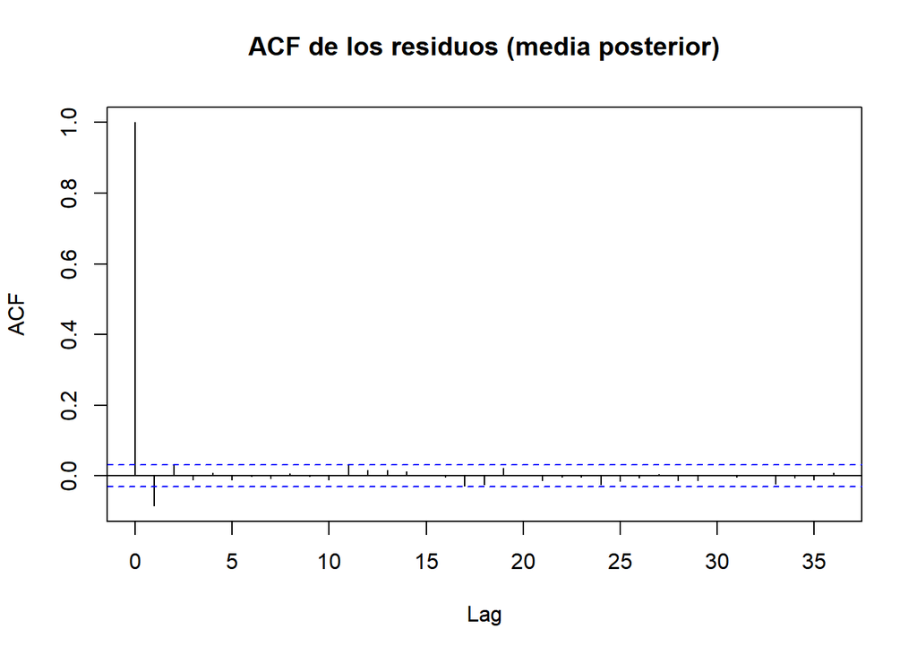

```r
res_medios <- apply(residuos, 1, mean)
acf(res_medios, main = "ACF de los residuos (media posterior)")
```

## 5.3 Comparación de ambos modelos

modelo_ar_error es el modelo con mejor desempeño predictivo, por eso aparece con elpd_diff = 0.0. Sirve como referencia.

modelo_normal tiene una diferencia de -16.8 puntos en elpd (expected log predictive density), lo que indica que predice significativamente peor que modelo_ar_error.

```r
loo_normal <- loo(modelo_normal)
loo_modelo_ar_error <- loo(modelo_ar_error)

# Nota: Para poder hacer esta comparación los modelos necesitan el mismo número de observaciones
comparacion_loo1 <- loo_compare(loo_normal, loo_modelo_ar_error)
print(comparacion_loo1)
```

```
##                 elpd_diff se_diff
## modelo_ar_error   0.0       0.0
## modelo_normal   -16.8       4.5
```

# 6 Modelo lognormal

```r
modelo_lognormal <- brm(
  pib_crecimiento ~ inversion + educacion + politica,
  data = datos,
  family = lognormal(),
  backend = "cmdstanr",
  threads = threading(4),
  prior = c(
    prior(normal(0, 1), class = "b"),
    prior(normal(0, 1), class = "Intercept"),
    prior(exponential(1), class = "sigma")
  ),
  chains = 4, iter = 2000, seed = 123, cores=4,
)
```

[output not shown]

[output cut: 43 more lines]

```
## Chain 4 Iteration: 1400 / 2000 [ 70%]  (Sampling)
## Chain 4 Iteration: 1500 / 2000 [ 75%]  (Sampling)
## Chain 4 Iteration: 1600 / 2000 [ 80%]  (Sampling)
## Chain 4 Iteration: 1700 / 2000 [ 85%]  (Sampling)
## Chain 4 Iteration: 1800 / 2000 [ 90%]  (Sampling)
## Chain 4 Iteration: 1900 / 2000 [ 95%]  (Sampling)
## Chain 4 Iteration: 2000 / 2000 [100%]  (Sampling)
## Chain 1 finished in 0.1 seconds.
## Chain 2 finished in 0.1 seconds.
## Chain 3 finished in 0.1 seconds.
## Chain 4 finished in 0.1 seconds.
##
## All 4 chains finished successfully.
## Mean chain execution time: 0.1 seconds.
## Total execution time: 61.0 seconds.
```

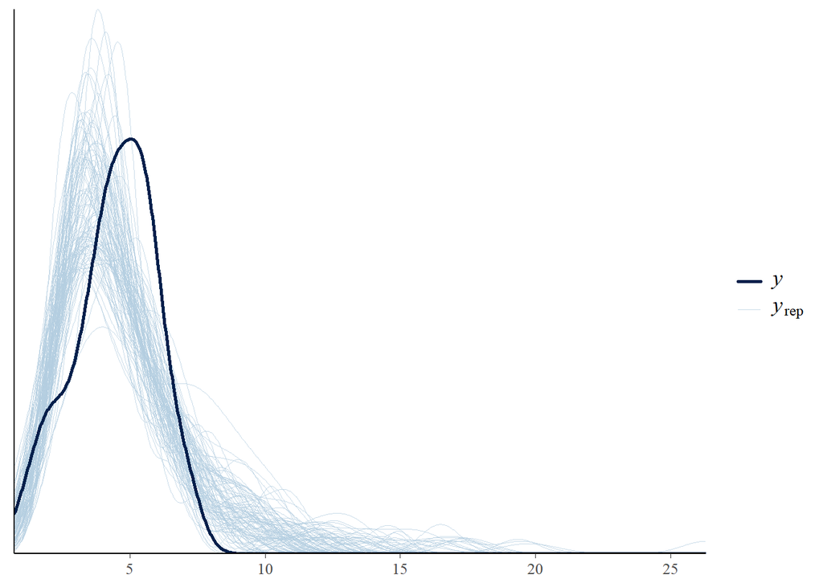

```r
pp_check(modelo_lognormal, nsamples = 100)
```

El modelo log_normal es el peor de los tres.

```r
loo_normal <- loo(modelo_normal)
loo_modelo_ar_error <- loo(modelo_ar_error)
loo_modelo_lognormal <- loo(modelo_lognormal)
# Nota: Para poder hacer esta comparación los modelos necesitan el mismo número de observaciones
comparacion_loo2 <- loo_compare(loo_normal, loo_modelo_ar_error, loo_modelo_lognormal)
print(comparacion_loo2)
```

```
##                  elpd_diff se_diff
## modelo_ar_error    0.0       0.0
## modelo_normal    -16.8       4.5
## modelo_lognormal -28.2       5.8
```

# 7 Modelo con distribución sesgada

El siguiente modelo asume que la tasa de crecimiento del PIB per cápita sigue una distribución **skew-normal** (asimétrica), en lugar de una distribución normal simétrica. La media del modelo está determinada por una combinación lineal de predictores:

$$\begin{align*}
y_t &\sim \text{SkewNormal}(\mu_t, \sigma, \alpha) \\
\mu_t &= \alpha_0 + \beta_1 \cdot \text{inversion}_t + \beta_2 \cdot
\text{educacion}_t + \beta_3 \cdot \text{politica}_t
\end{align*}$$

Donde:

- $y_t$ es la tasa de crecimiento del PIB per cápita en el año $t$,
- $\text{inversion}_t$ es la tasa de crecimiento de inversión en tecnología,
- $\text{educacion}_t$ es el crecimiento en escolaridad promedio,
- $\text{politica}_t \in \{0, 1\}$ indica la presencia de una política pública,
- $\sigma$ es el parámetro de escala (desviación estándar),
- $\alpha$ (no confundir con el intercepto) es el parámetro de **asimetría** de la distribución.

Las distribuciones a priori utilizadas para los parámetros fueron:

$$\begin{align*}
\alpha_0 &\sim \mathcal{N}(0, 1) \\
\beta_j &\sim \mathcal{N}(0, 1) \quad \text{para } j = 1, 2, 3 \\
\sigma &\sim \mathcal{N}^{+}(0, 2) \quad \text{(truncada a valores
positivos)} \\
\alpha &\sim \mathcal{N}(0, 1)
\end{align*}$$

Este modelo permite capturar posibles **asimetrías en la distribución de los errores**, lo cual es especialmente útil si los datos presentan colas más largas hacia un lado o sesgos sistemáticos no explicados por los predictores.

```r
modelo_skew <- brm(
  pib_crecimiento ~ inversion + educacion + politica,
  data = datos,
  backend = "cmdstanr",
  threads = threading(14),
  family = skew_normal(),
  prior = c(
    prior(normal(0, 1), class = "b"),
    prior(normal(0, 1), class = "Intercept"),
    prior(normal(0, 2), class = "sigma"),
    prior(normal(0, 1), class = "alpha")
  ),
  chains = 4, iter = 2000, seed = 123, cores=4,
)
```

[output not shown]

[output cut: 43 more lines]

```
## Chain 1 finished in 0.2 seconds.
## Chain 2 finished in 0.2 seconds.
## Chain 3 finished in 0.1 seconds.
## Chain 4 Iteration: 1400 / 2000 [ 70%]  (Sampling)
## Chain 4 Iteration: 1500 / 2000 [ 75%]  (Sampling)
## Chain 4 Iteration: 1600 / 2000 [ 80%]  (Sampling)
## Chain 4 Iteration: 1700 / 2000 [ 85%]  (Sampling)
## Chain 4 Iteration: 1800 / 2000 [ 90%]  (Sampling)
## Chain 4 Iteration: 1900 / 2000 [ 95%]  (Sampling)
## Chain 4 Iteration: 2000 / 2000 [100%]  (Sampling)
## Chain 4 finished in 0.1 seconds.
##
## All 4 chains finished successfully.
## Mean chain execution time: 0.1 seconds.
## Total execution time: 61.0 seconds.
```

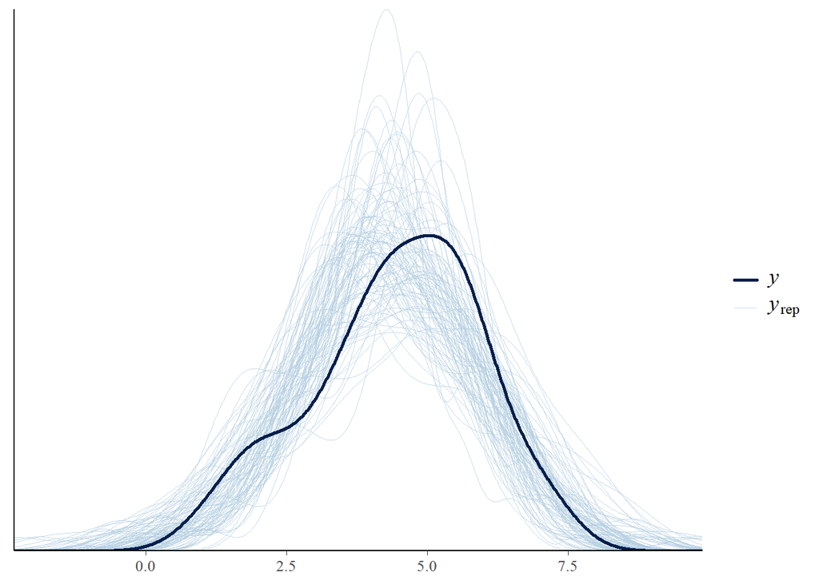

```r
pp_check(modelo_skew, nsamples = 100)
```

```r
loo_skew <- loo(modelo_skew)

comparacion_loo4 <- loo_compare(loo_normal, loo_modelo_lognormal, loo_skew, loo_modelo_ar_error)
print(comparacion_loo4)
```

```
##                  elpd_diff se_diff
## modelo_ar_error    0.0       0.0
## modelo_skew      -16.6       4.4
## modelo_normal    -16.8       4.5
## modelo_lognormal -28.2       5.8
```

# 8 Modelo AR(1)

```r
modelo_ar_sknormal_error <- brm(
  pib_crecimiento ~ inversion_lag1 + educacion + politica,
  data = datos,
  family = skew_normal(),
  autocor = cor_ar(~ anio | 1, p = 1),
  backend = "cmdstanr",
  chains = 4, iter = 2500, seed = 123, cores = 10,
  prior = c(
    prior(normal(0, 1), class = "b"),
    prior(normal(3, 1), class = "Intercept"),
    prior(normal(0, 2), class = "sigma"),
    prior(normal(0, 1), class = "alpha")
  )
)
```

[output not shown]

[output cut: 63 more lines]

```
## Chain 4 Iteration: 1650 / 2500 [ 66%]  (Sampling)
## Chain 4 Iteration: 1750 / 2500 [ 70%]  (Sampling)
## Chain 4 Iteration: 1850 / 2500 [ 74%]  (Sampling)
## Chain 4 Iteration: 1950 / 2500 [ 78%]  (Sampling)
## Chain 4 Iteration: 2050 / 2500 [ 82%]  (Sampling)
## Chain 4 Iteration: 2150 / 2500 [ 86%]  (Sampling)
## Chain 4 Iteration: 2250 / 2500 [ 90%]  (Sampling)
## Chain 4 Iteration: 2350 / 2500 [ 94%]  (Sampling)
## Chain 4 Iteration: 2450 / 2500 [ 98%]  (Sampling)
## Chain 4 Iteration: 2500 / 2500 [100%]  (Sampling)
## Chain 4 finished in 0.8 seconds.
##
## All 4 chains finished successfully.
## Mean chain execution time: 1.1 seconds.
## Total execution time: 61.5 seconds.
```

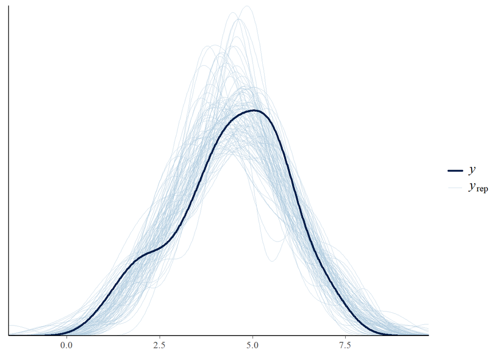

```r
pp_check(modelo_ar_sknormal_error, nsamples = 100)
```

El modelo con autocorrelación AR(1) en los errores (modelo_ar_error) es el que presenta mejor capacidad predictiva, por lo tanto se utiliza como referencia (elpd_diff = 0.0).

Los modelos modelo_skew y modelo_normal, que no incorporan autocorrelación, tienen un ajuste predictivo considerablemente peor, con una diferencia de más de 16 puntos en el elpd.

```r
loo_modelo_ar_sknormal_error <- loo(modelo_ar_sknormal_error)

comparacion_loo4 <- loo_compare(loo_normal, loo_modelo_lognormal, loo_modelo_ar_error, loo_skew, loo_modelo_ar_sknormal_error)
print(comparacion_loo4)
```

```
##                          elpd_diff se_diff
## modelo_ar_error            0.0       0.0
## modelo_ar_sknormal_error -13.2       5.0
## modelo_skew              -16.6       4.4
## modelo_normal            -16.8       4.5
## modelo_lognormal         -28.2       5.8
```

# 9 COmparación de posteriores

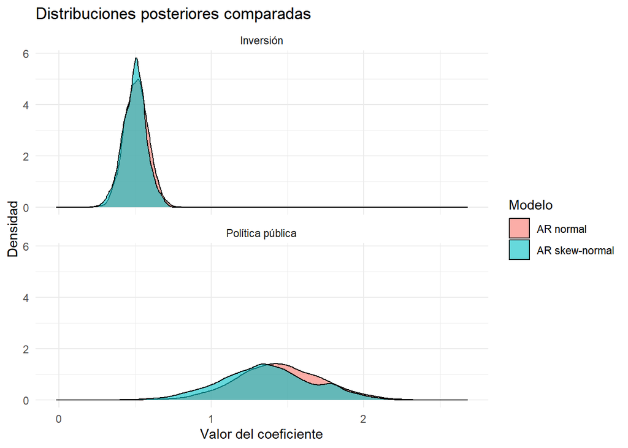

```r
library(posterior)
library(ggplot2)
library(dplyr)
library(tidyr)

# Extraer draws y agregar columna de modelo
post_ar <- as_draws_df(modelo_ar_error) %>%
  mutate(modelo = "AR normal")

post_ar_skew <- as_draws_df(modelo_ar_sknormal_error) %>%
  mutate(modelo = "AR skew-normal")

# Unir y seleccionar las variables de interés
post_combined <- bind_rows(post_ar, post_ar_skew) %>%
  select(`b_inversion_lag1`, `b_politica1`, modelo) %>%
  pivot_longer(
    cols = starts_with("b_"),
    names_to = "parámetro",
    values_to = "valor"
  )

# Renombrar para claridad
post_combined$parámetro <- recode(post_combined$parámetro,
                                  `b_inversion_lag1` = "Inversión",
                                  `b_politica1` = "Política pública")

# Gráfico
ggplot(post_combined, aes(x = valor, fill = modelo)) +
  geom_density(alpha = 0.6) +
  facet_wrap(~parámetro, scales = "fixed", ncol = 1) +
  labs(
    title = "Distribuciones posteriores comparadas",
    x = "Valor del coeficiente",
    y = "Densidad",
    fill = "Modelo"
  ) +
  theme_minimal()
```